# Assignment 1

### Box plot after normalization

After normalization, the median of each sample differ less to each other than before, which makes the data more comparable. The number of outlier genes (above the maxium point in the boxplots) in each sample remains unchanged. Note that the box plots seemed to have normal distributions as the medians are located at the center of each box.

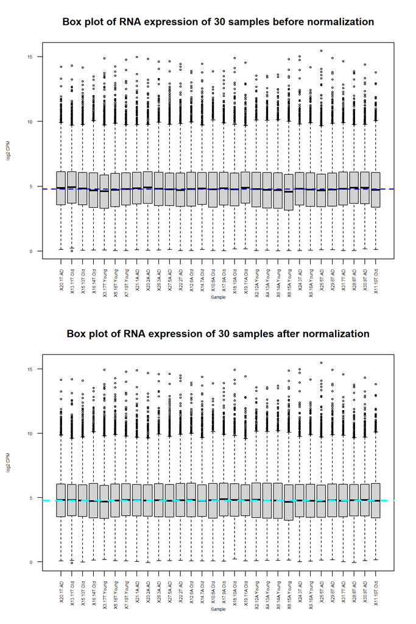

```r
par(mfrow = c(2, 1))

boxplot(b3plot, xlab = "Sample", ylab = "log2 CPM",
las = 2, cex = 0.5, cex.lab = 0.5,
cex.axis = 0.5, main = "Box plot of RNA expression of 30 samples before normalization")

abline(h = median(apply(b3plot, 2, median)),
col = "blue3", lwd = 2, lty = "dashed")

boxplot(log2(normalized_data), xlab = "Sample", ylab = "log2 CPM",
las = 2, cex = 0.5, cex.lab = 0.5,
cex.axis = 0.5, main = "Box plot of RNA expression of 30 samples after normalization")

abline(h = median(apply(b3plot, 2, median)),
col = "cyan", lwd = 3, lty = "dashed")
```

### Density plots after normalization

There is no significant change in the density plot after normalization.

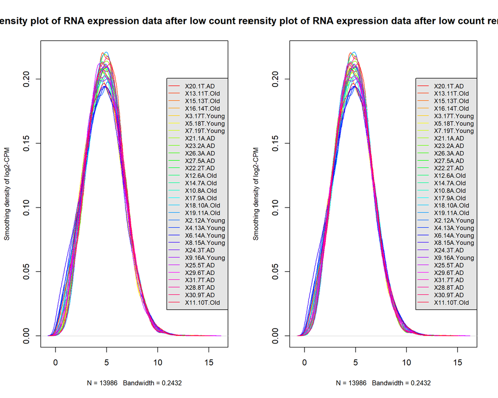

```r
par(mfrow = c(1, 2))

plot_Density(b3plot)
plot_Density(log2(normalized_data))
```

### MDS Plot after normalization

```r
samples <- data.frame(lapply(colnames(normalized_data)[1:31],
        FUN=function(x){unlist(strsplit(x,
                        split = "\\."))}))
colnames(samples) <- colnames(normalized_data)[1:31]
rownames(samples) <- c("sample_number", "A_T", "disease_type")
samples <- data.frame(t(samples))
samples <- samples[1:30, ]
```

From the MDS Plot, three clusters are observed. The green one representing the AD population clusters in the center, while the old population clusters at the left hand side of the graph. Red, representing young population in the sample, scatter across x a-xis, but does not have a y value higher than 0.5.

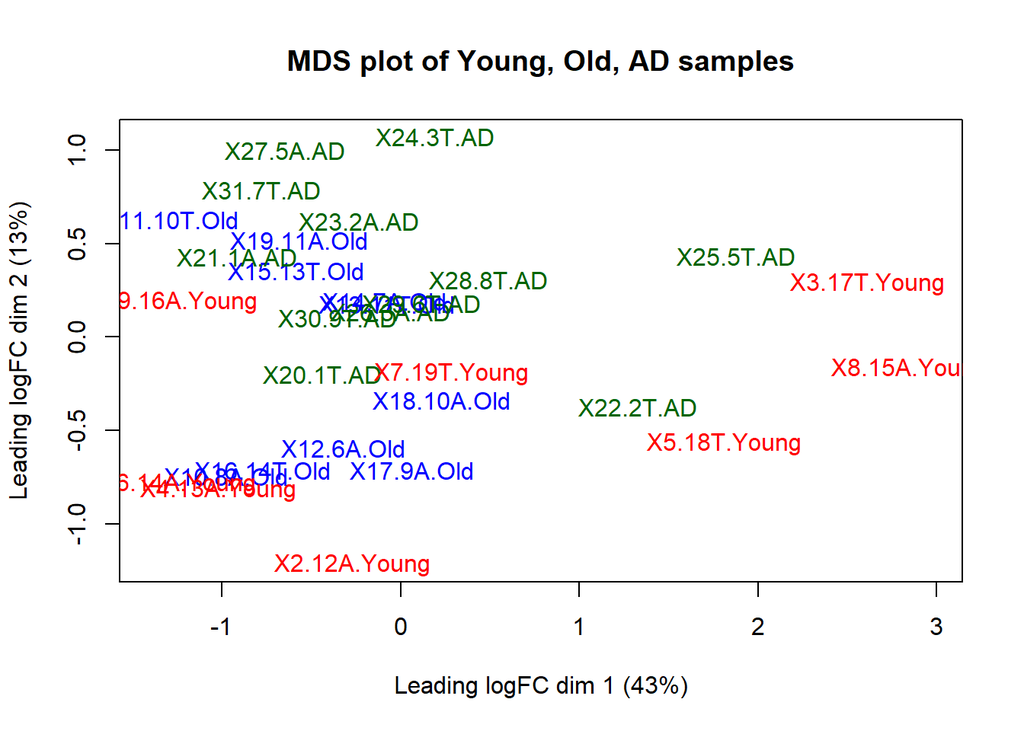

```r
plotMDS(d, labels=rownames(samples),
col = c("darkgreen","blue", "red")[factor(samples$disease_type)],
main="MDS plot of Young, Old, AD samples")
```

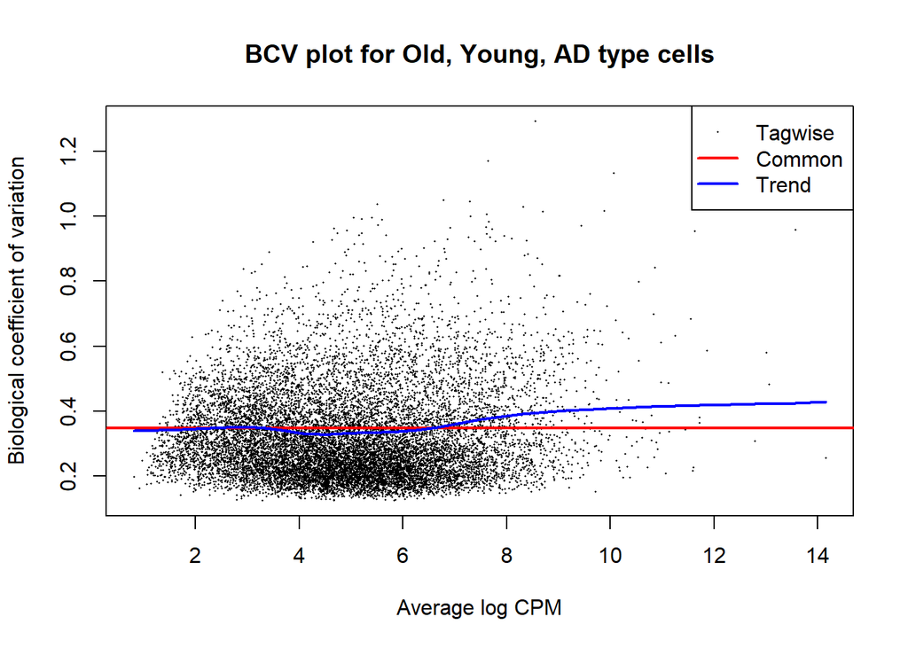

```r
# warning shown when model design is included in the calculation of dispersion. Omitted for now.
model_design <- model.matrix(~samples$disease_type +   0)
bcv_d <- estimateDisp(d, model_design)

plotBCV(bcv_d, col.tagwise = "black",col.common = "red",
        main= "BCV plot for Old, Young, AD type cells")
```